# Course Project 2: Exploration of the NOAA Storm Database

## Synopsis

Severe weather refers to any dangerous meteorological phenomena with the potential to cause damage, serious social disruption, or loss of human life. We will explore data of the National Oceanic & Atmospheric Administration to give the answers to the following questions:

1. Across the United States, which types of events are most harmful with respect to population health?
2. Across the United States, which types of events have the greatest economic consequences?

The events in the database start in the year 1950 and end in November 2011. In the earlier years of the database there are generally fewer events recorded, most likely due to a lack of good records. More recent years should be considered more complete.

The results of this exploration could use for prioritization of research on severe weather prediction.

## Data Processing

```r
library(dplyr)
```

```r
library(ggplot2)
library(reshape2)
library(forcats)
# read data
StormData <- read.csv("StormData.csv.bz2", stringsAsFactors = FALSE)

# CLEANING DATA
# add new column for permitted storm data events (according instruction)
StormData$evtype <- tolower(StormData$EVTYPE)

# transform EVTYPE to the permitted storm data events (from instruction) to prevent loosing numbers. Some event types describe absolutly the same

StormData$evtype[StormData$evtype == 'avalance'] <- 'avalanche'
StormData$evtype[StormData$evtype == 'blowing snow'] <- 'blizzard'
StormData$evtype[StormData$evtype == 'blizzard/winter storm'] <- 'blizzard'
StormData$evtype[StormData$evtype == 'cold'] <- 'cold/wind chill'
StormData$evtype[StormData$evtype == 'cold and wet conditions'] <- 'cold/wind chill'
StormData$evtype[StormData$evtype == 'cold temprature'] <- 'cold/wind chill'
StormData$evtype[StormData$evtype == 'cold wave'] <- 'cold/wind chill'
StormData$evtype[StormData$evtype == 'cold/winds'] <- 'cold/wind chill'
StormData$evtype[StormData$evtype == 'low temperature'] <- 'cold/wind chill'
StormData$evtype[StormData$evtype == 'unseasonably cold'] <- 'cold/wind chill'
StormData$evtype[StormData$evtype == 'cold temperature'] <- 'cold/wind chill'
StormData$evtype[StormData$evtype == 'cold wave'] <- 'cold/wind chill'
StormData$evtype[StormData$evtype == 'cold weather'] <- 'cold/wind chill'
StormData$evtype[StormData$evtype == 'cold/winds'] <- 'cold/wind chill'
StormData$evtype[StormData$evtype == 'extreme cold'] <- 'extreme cold/wind chill'
StormData$evtype[StormData$evtype == 'extreme cold/wind chill'] <- 'extreme cold/wind chill'
StormData$evtype[StormData$evtype == 'extreme windchill'] <- 'extreme cold/wind chill'
StormData$evtype[StormData$evtype == 'extended cold'] <- 'extreme cold/wind chill'
StormData$evtype[StormData$evtype == 'record cold'] <- 'extreme cold/wind chill'
StormData$evtype[StormData$evtype == 'extreme wind chill'] <- 'extreme cold/wind chill'
StormData$evtype[StormData$evtype == 'extreme heat'] <- 'excessive heat'
StormData$evtype[StormData$evtype == 'record/excessive heat'] <- 'excessive heat'
StormData$evtype[StormData$evtype == 'flash flooding'] <- 'flash flood'
StormData$evtype[StormData$evtype == 'flood/flash flood'] <- 'flood'
StormData$evtype[StormData$evtype == 'flooding'] <- 'flood'
StormData$evtype[StormData$evtype == 'river flood'] <- 'flood'
StormData$evtype[StormData$evtype == 'river flooding'] <- 'flood'
StormData$evtype[StormData$evtype == 'drowning'] <- 'flood'
StormData$evtype[StormData$evtype == 'flood/rain/winds'] <- 'flood'
StormData$evtype[StormData$evtype == 'flood/river flood'] <- 'flood'
StormData$evtype[StormData$evtype == '  floods'] <- 'flood'
StormData$evtype[StormData$evtype == 'excessive rainfall'] <- 'flash flood'
StormData$evtype[StormData$evtype == 'flood & heavy rain'] <- 'flash flood'
StormData$evtype[StormData$evtype == 'flash floods'] <- 'flash flood'
StormData$evtype[StormData$evtype == 'flash flooding/flood'] <- 'flash flood'
StormData$evtype[StormData$evtype == 'flash flood/flood'] <- 'flash flood'
StormData$evtype[StormData$evtype == ' flash flood'] <- 'flash flood'
StormData$evtype[StormData$evtype == 'flash flood - heavy rain'] <- 'flash flood'
StormData$evtype[StormData$evtype == 'flash flood from ice jams'] <- 'flash flood'
StormData$evtype[StormData$evtype == 'flash flood/'] <- 'flash flood'
StormData$evtype[StormData$evtype == 'coastal flooding'] <- 'coastal flood'
StormData$evtype[StormData$evtype == 'coastal flooding/erosion'] <- 'coastal flood'
StormData$evtype[StormData$evtype == 'coastal  flooding/erosion'] <- 'coastal flood'
StormData$evtype[StormData$evtype == 'erosion/cstl flood'] <- 'coastal flood'
StormData$evtype[StormData$evtype == 'frost'] <- 'frost/freeze'
StormData$evtype[StormData$evtype == 'black ice'] <- 'frost/freeze'
StormData$evtype[StormData$evtype == 'glaze'] <- 'frost/freeze'
StormData$evtype[StormData$evtype == 'ice'] <- 'frost/freeze'
StormData$evtype[StormData$evtype == 'icy roads'] <- 'frost/freeze'
StormData$evtype[StormData$evtype == 'ice on road'] <- 'frost/freeze'
StormData$evtype[StormData$evtype == 'ice roads'] <- 'frost/freeze'
StormData$evtype[StormData$evtype == 'agricultural freeze'] <- 'frost/freeze'
StormData$evtype[StormData$evtype == 'damaging freeze'] <- 'frost/freeze'
StormData$evtype[StormData$evtype == 'early frost'] <- 'frost/freeze'
StormData$evtype[StormData$evtype == 'frost\freeze'] <- 'frost/freeze'
StormData$evtype[StormData$evtype == 'hard freeze'] <- 'frost/freeze'
StormData$evtype[StormData$evtype == 'gusty winds'] <- 'gusty wind'
StormData$evtype[StormData$evtype == 'heat wave drought'] <- 'drought'
StormData$evtype[StormData$evtype == 'drought/excessive heat'] <- 'drought'
StormData$evtype[StormData$evtype == 'heat wave'] <- 'heat'
StormData$evtype[StormData$evtype == 'record heat'] <- 'heat'
StormData$evtype[StormData$evtype == 'unseasonably warm'] <- 'heat'
StormData$evtype[StormData$evtype == 'heavy surf'] <- 'high surf'
StormData$evtype[StormData$evtype == 'heavy surf/high surf'] <- 'high surf'
StormData$evtype[StormData$evtype == 'rough surf'] <- 'high surf'
StormData$evtype[StormData$evtype == 'hazardous surf'] <- 'high surf'
StormData$evtype[StormData$evtype == 'high waves'] <- 'high surf'
StormData$evtype[StormData$evtype == 'high winds'] <- 'high wind'
StormData$evtype[StormData$evtype == 'high wind  and seas'] <- 'high wind'
StormData$evtype[StormData$evtype == 'landslide'] <- 'debris flow'
StormData$evtype[StormData$evtype == 'land slides'] <- 'debris flow'
StormData$evtype[StormData$evtype == 'landslides'] <- 'debris flow'
StormData$evtype[StormData$evtype == 'mudslide'] <- 'debris flow'
StormData$evtype[StormData$evtype == 'mudslides'] <- 'debris flow'
StormData$evtype[StormData$evtype == 'marine tstm wind'] <- 'marine thunderstorm wind'
StormData$evtype[StormData$evtype == 'rip currents'] <- 'rip current'
StormData$evtype[StormData$evtype == 'rip currents/heavy surf'] <- 'rip current'
StormData$evtype[StormData$evtype == 'strong winds'] <- 'strong wind'
StormData$evtype[StormData$evtype == 'gusty wind'] <- 'strong wind'
StormData$evtype[StormData$evtype == 'gusty winds'] <- 'strong wind'
StormData$evtype[StormData$evtype == 'winds'] <- 'strong wind'
StormData$evtype[StormData$evtype == 'wind'] <- 'strong wind'
StormData$evtype[StormData$evtype == 'hurricane erin'] <- 'hurricane/typhoon'
StormData$evtype[StormData$evtype == 'hurricane opal'] <- 'hurricane/typhoon'
StormData$evtype[StormData$evtype == 'hurricane opal/high winds'] <- 'hurricane/typhoon'
StormData$evtype[StormData$evtype == 'hurricane edouard'] <- 'hurricane/typhoon'
StormData$evtype[StormData$evtype == 'hurricane emily'] <- 'hurricane/typhoon'
StormData$evtype[StormData$evtype == 'hurricane felix'] <- 'hurricane/typhoon'
StormData$evtype[StormData$evtype == 'hurricane gordon'] <- 'hurricane/typhoon'
StormData$evtype[StormData$evtype == 'hurricane'] <- 'hurricane/typhoon'
StormData$evtype[StormData$evtype == 'typhoon'] <- 'hurricane/typhoon'
StormData$evtype[StormData$evtype == 'dry microburst'] <- 'thunderstorm wind'
StormData$evtype[StormData$evtype == 'dry mircoburst winds'] <- 'thunderstorm wind'
StormData$evtype[StormData$evtype == 'thunderstorm winds'] <- 'thunderstorm wind'
StormData$evtype[StormData$evtype == 'thunderstorm'] <- 'thunderstorm wind'
StormData$evtype[StormData$evtype == 'thundersnow'] <- 'thunderstorm wind'
StormData$evtype[StormData$evtype == 'thunderstorm winds'] <- 'thunderstorm wind'
StormData$evtype[StormData$evtype == 'thunderstorm wind (g40)'] <- 'thunderstorm wind'
StormData$evtype[StormData$evtype == 'thunderstorm wind g52'] <- 'thunderstorm wind'
StormData$evtype[StormData$evtype == 'thunderstorm winds 13'] <- 'thunderstorm wind'
StormData$evtype[StormData$evtype == 'thunderstorm windss'] <- 'thunderstorm wind'
StormData$evtype[StormData$evtype == 'thunderstorms winds'] <- 'thunderstorm wind'
StormData$evtype[StormData$evtype == 'thunderstorm winds/hail'] <- 'thunderstorm wind'
StormData$evtype[StormData$evtype == 'thunderstormw'] <- 'thunderstorm wind'
StormData$evtype[StormData$evtype == 'thundertormw winds'] <- 'thunderstorm wind'
StormData$evtype[StormData$evtype == 'tstm wind (g35)'] <- 'thunderstorm wind'
StormData$evtype[StormData$evtype == 'tstm wind (g40)'] <- 'thunderstorm wind'
StormData$evtype[StormData$evtype == 'tstm wind (g45)'] <- 'thunderstorm wind'
StormData$evtype[StormData$evtype == ' tstm wind'] <- 'thunderstorm wind'
StormData$evtype[StormData$evtype == ' tstm wind (g45)'] <- 'thunderstorm wind'
StormData$evtype[StormData$evtype == 'freezing drizzle'] <- 'winter weather'
StormData$evtype[StormData$evtype == 'freezing rain'] <- 'winter weather'
StormData$evtype[StormData$evtype == 'light snow'] <- 'winter weather'
StormData$evtype[StormData$evtype == 'snow'] <- 'winter weather'
StormData$evtype[StormData$evtype == 'snow and ice'] <- 'winter weather'
StormData$evtype[StormData$evtype == 'winter weather/mix'] <- 'winter weather'
StormData$evtype[StormData$evtype == 'winter weather mix'] <- 'winter weather'
StormData$evtype[StormData$evtype == 'wintry mix'] <- 'winter weather'
StormData$evtype[StormData$evtype == 'falling snow/ice'] <- 'winter weather'
StormData$evtype[StormData$evtype == 'cold and snow'] <- 'winter weather'
StormData$evtype[StormData$evtype == 'winter storms'] <- 'winter storm'
StormData$evtype[StormData$evtype == 'heavy snow and high winds'] <- 'winter storm'
StormData$evtype[StormData$evtype == 'snow squall'] <- 'winter storm'
StormData$evtype[StormData$evtype == 'snow squalls'] <- 'winter storm'
StormData$evtype[StormData$evtype == 'glaze/ ice storm'] <- 'ice storm'
StormData$evtype[StormData$evtype == 'ice storm/flash flood'] <- 'ice storm'
StormData$evtype[StormData$evtype == 'heavy snow shower'] <- 'heavy snow'
StormData$evtype[StormData$evtype == 'heavy snow/ice'] <- 'heavy snow'
StormData$evtype[StormData$evtype == 'coastal storm'] <- 'tropical storm'
StormData$evtype[StormData$evtype == 'coastalstorm'] <- 'tropical storm'
StormData$evtype[StormData$evtype == 'tropical storm gordon'] <- 'tropical storm'
StormData$evtype[StormData$evtype == 'storm surge'] <- 'storm surge/tide'
StormData$evtype[StormData$evtype == 'tstm wind'] <- 'tsunami'
StormData$evtype[StormData$evtype == 'tstm wind/hail'] <- 'tsunami'
StormData$evtype[StormData$evtype == 'waterspout'] <- 'tornado'
StormData$evtype[StormData$evtype == 'waterspout/tornado'] <- 'tornado'
StormData$evtype[StormData$evtype == 'tornado f2'] <- 'tornado'
StormData$evtype[StormData$evtype == 'tornado f3'] <- 'tornado'
StormData$evtype[StormData$evtype == 'tornadoes, tstm wind, hail'] <- 'tornado'
StormData$evtype[StormData$evtype == 'waterspout tornado'] <- 'tornado'
StormData$evtype[StormData$evtype == 'urban/sml stream fld'] <- 'heavy rain'
StormData$evtype[StormData$evtype == 'heavy rains'] <- 'heavy rain'
StormData$evtype[StormData$evtype == 'heavy rain/severe weather'] <- 'heavy rain'
StormData$evtype[StormData$evtype == 'wild fires'] <- 'wildfires'
StormData$evtype[StormData$evtype == 'wildfires'] <- 'wildfires'
StormData$evtype[StormData$evtype == 'wild/forest fire'] <- 'wildfires'
StormData$evtype[StormData$evtype == 'lightning.'] <- 'lightning'
StormData$evtype[StormData$evtype == 'lightning injury'] <- 'lightning'
StormData$evtype[StormData$evtype == 'small hail'] <- 'hail'
StormData$evtype[StormData$evtype == 'hail 0.75'] <- 'hail'
StormData$evtype[StormData$evtype == 'hail 075'] <- 'hail'
StormData$evtype[StormData$evtype == 'hail 100'] <- 'hail'
StormData$evtype[StormData$evtype == 'hail 125'] <- 'hail'
StormData$evtype[StormData$evtype == 'hail 150'] <- 'hail'
StormData$evtype[StormData$evtype == 'hail 175'] <- 'hail'
StormData$evtype[StormData$evtype == 'hail 200'] <- 'hail'
StormData$evtype[StormData$evtype == 'hail 275'] <- 'hail'
StormData$evtype[StormData$evtype == 'hail 450'] <- 'hail'
StormData$evtype[StormData$evtype == 'hail 75'] <- 'hail'
StormData$evtype[StormData$evtype == 'hail damage'] <- 'hail'
```

```r
StormData$evtype[StormData$evtype == 'hail/wind'] <- 'hail'
StormData$evtype[StormData$evtype == 'hail/winds'] <- 'hail'
StormData$evtype[StormData$evtype == 'hailstorm'] <- 'hail'

# corvert evtype to factor
StormData$evtype <- as.factor(StormData$evtype)

# adding new columns for transformation letter describing multiplier
StormData$propexp <- StormData$PROPDMGEXP
StormData$cropexp <- StormData$CROPDMGEXP

# replace letter with according multiplier
StormData$propexp <- gsub("b", 1000000000, StormData$propexp, ignore.case = TRUE)
StormData$propexp <- gsub("m", 1000000, StormData$propexp, ignore.case = TRUE)
StormData$propexp <- gsub("k", 1000, StormData$propexp, ignore.case = TRUE)
StormData$propexp <- gsub("h", 100, StormData$propexp, ignore.case = TRUE)
StormData$cropexp <- gsub("b", 1000000000, StormData$cropexp, ignore.case = TRUE)
StormData$cropexp <- gsub("m", 1000000, StormData$cropexp, ignore.case = TRUE)
StormData$cropexp <- gsub("k", 1000, StormData$cropexp, ignore.case = TRUE)
StormData$cropexp <- gsub("h", 100, StormData$cropexp, ignore.case = TRUE)
# convert to numeric
StormData$propexp <- as.numeric(StormData$propexp)
StormData$cropexp <- as.numeric(StormData$cropexp)
# summarise Fatalities, Injuries, Prop&Crop Damage per event type
gr.evtype <- StormData %>% group_by(evtype) %>% summarise(fatal = sum(FATALITIES),
        injur= sum(INJURIES), propcrop = sum(PROPDMG * propexp, na.rm = TRUE) + sum(CROPDMG*cropexp, na.rm = TRUE))

# create data frame for health data
health.evtype <- filter(gr.evtype, (fatal != 0 | injur != 0))
# create data frame for economic data
dmg.evtype <- filter(gr.evtype, (propcrop != 0))

# calculate proportions for every event type
health.evtype$prop_fatal <- health.evtype$fatal/sum(health.evtype$fatal) * 100
health.evtype$prop_injur <- health.evtype$injur/sum(health.evtype$injur) * 100

dmg.evtype$prop_pc <- dmg.evtype$propcrop/sum(dmg.evtype$propcrop) * 100

# set the significant level 80%
sign_level <- 80

# make a new data frame with event types describing significant level of injuries
health.evtype <- health.evtype %>% select(evtype, fatal,injur, prop_fatal, prop_injur) %>% arrange(desc(injur))
injures_sum <- 0
mostinjures <- NULL
for (i in 1:nrow(health.evtype)) {
    mostinjures <- rbind(mostinjures,health.evtype[i,c(1,3,5)])
    injures_sum <- injures_sum + health.evtype$prop_injur[i]
    goal <-  ifelse(injures_sum >= sign_level, TRUE, FALSE)
    if (goal == TRUE) {
        break
    }
}
# make a new data frame with evtypes describing significant level of fatalities
health.evtype <- arrange(health.evtype , desc(fatal))
fatal_sum <- 0
mostfatal <- NULL
for (i in 1:nrow(health.evtype)) {
    mostfatal <- rbind(mostfatal,health.evtype[i,c(1,2,4)])
    fatal_sum <- fatal_sum + health.evtype$prop_fatal[i]
    goal <-  ifelse(fatal_sum >= sign_level, TRUE, FALSE)
    if (goal == TRUE) {
        break
    }
}
# make the new data frames with evtypes describing significant level of prop&crop damage
dmg.evtype <- dmg.evtype %>% select(evtype, propcrop, prop_pc) %>% arrange(desc(propcrop))
prop_sum <- 0
mostpropcrop <- NULL
for (i in 1:nrow(health.evtype)) {
    mostpropcrop <- rbind(mostpropcrop,dmg.evtype[i,c(1,2,3)])
    prop_sum <- prop_sum + dmg.evtype$prop_pc[i]
    goal <-  ifelse(prop_sum >= sign_level, TRUE, FALSE)
    if (goal == TRUE) {
        break
    }
}
# sort event types in descending order of injures
mostinjures$evtype <- fct_reorder(mostinjures$evtype,mostinjures$injur)
# create barplot for injuries
I_plot <- ggplot(mostinjures, aes(x = evtype, y = injur, fill = evtype)) +
    geom_col(colour = 'black') +
    labs(title = 'Injuries per Event Type* in USA (1950 - 2011)',
         subtitle = "*event types describing 80% of total injuries",
         x = "Event type",  y = "Injuries") +
    coord_flip() +
    theme_bw() +
    theme(legend.position = "none") +
    scale_fill_brewer(palette = "Set1")

# sort event types in descending order of fatalities
mostfatal$evtype <- fct_reorder(mostfatal$evtype,mostfatal$fatal)
# create barplot for fatalities
F_plot <- ggplot(mostfatal, aes(x = evtype, y = fatal, fill = evtype)) +
    geom_col(colour = 'black', ) +
    labs(title = 'Fatalities per Event Type* in USA (1950-2011)',
         subtitle = "*event types describing 80% of total fatalities",
         x = "Event type", y = "Fatalities") +
    coord_flip() +
    theme_bw() +
    theme(legend.position = "none") +
    scale_fill_brewer(palette = "Set1")

# sort event types in descending order of fatalities
mostpropcrop$evtype <- fct_reorder(mostpropcrop$evtype,mostpropcrop$propcrop)
# create barplot for economic consequences
D_plot <- ggplot(mostpropcrop, aes(x = evtype, y = propcrop/1000000000, fill = evtype)) +
    geom_col(colour = 'black') +
    labs(title = "Damage per Event Type* in USA (1950-2011)",
         subtitle = "*event types describing 80% of total damage ",
         x = "Event type", y = "Damage (billion dollars)") +
    coord_flip() +
    theme_bw() +
    theme(legend.position = "none") +
    scale_fill_brewer(palette = "Set1")
```

## Results

**1. Across the United States, which types of events are most harmful with respect to population health?**

Let’s see injuries (figure 1) and fatalities (figure 2) separatly. There are only event types on the plots describing 80% of cases.

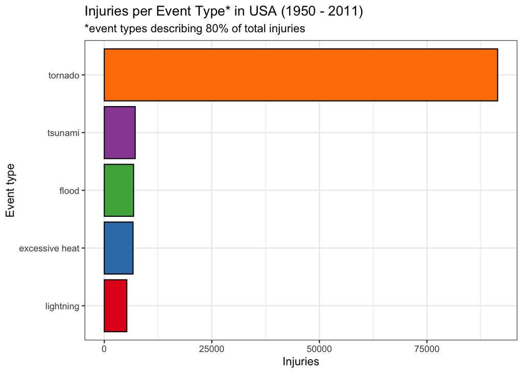

Figure 1. Injureis

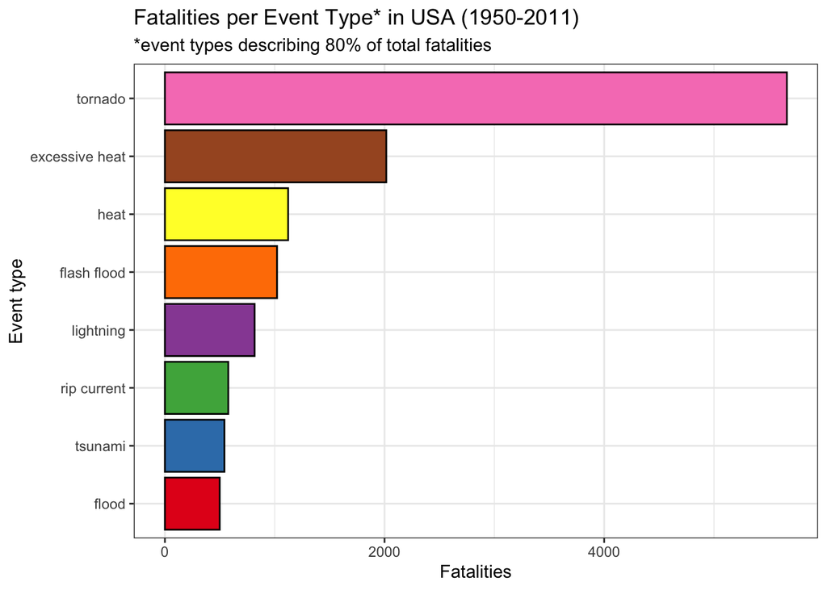

Figure 2. Fatalaties

As we can see in both casese **tornado** is the most harmful with respect to population health.

**2. Across the United States, which types of events have the greatest economic consequences?**

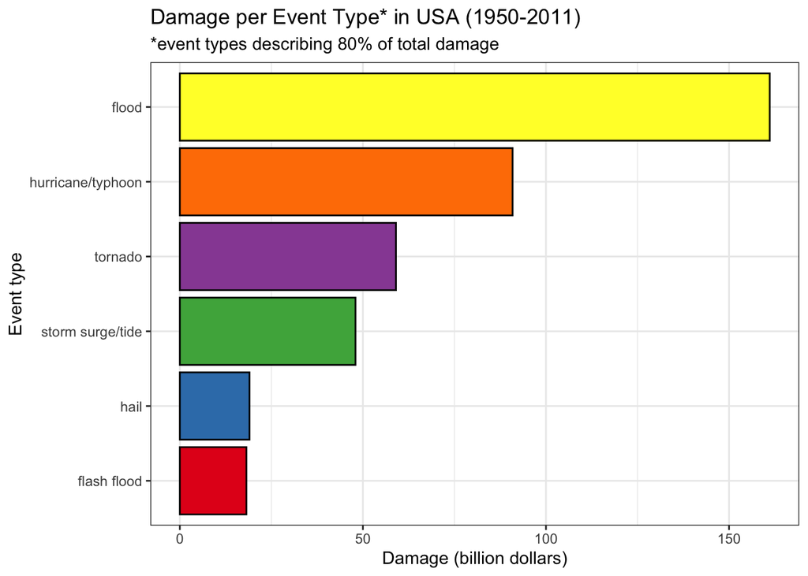

Therefore **floods** have the greatest economic consequences.